# Boston Housing Prices

Camron Khan  
April 2017

## Setup

```r
#install.packages("caret")
library(caret)
```

```r
rawData <- read.csv('./Boston.csv', stringsAsFactors = FALSE)
```

```r
set.seed(1)
```

## EDA

**Data Types**  
Most features are doubles; however, we have three features - *chas, rad, and tax* - that are integers. The feature *chas* is clearly categorical and has already been dummied; however, we must decide how to treat *rad* and *tax*. There’s not enough information to make a clear judgment about *rad* - it’s not clear if the “index of accessibility to radial highways” is referring to the number of access points availble or simply to an arbitrary scoring. As a result, this variable must be dummied. The feature *tax*, however, is referring to the property tax rate per $10,000. Therefore, this appears to be better classified as a continuous value. It appears the index is included as a feature that we will need to remove from our dataframe. We will consider additional features to prune later in the analysis.

**Missing Values**  
Surprisingly, there are no missing values in this dataset; and therefore, there is no need for imputations.

**Distributions**  
Below are the distributions for continuous variables:

- Normally Distributed: *rm*
- Left-Skewed: *age*, *ptratio*, *black*
- Right-Skewed: *crim*, *zn*, *nox*, *dis*, *lstat*, *medv*
- Unclassified: *indus*, *tax*

**Transformations**  
It may be worth performing a transformation on *tax* to get the tax rate as a percent (i.e., divide by $10,000) for readability. All non-categorical features are postive with the exception of *zn*; therefore, we will need to devise a strategy for handling this feature if we want to use Box-Cox transformations to reduce skew.

```r
feature <- as.vector(colnames(rawData))
definition <- c("index", "per capita crime rate by town", "proportion of residential land zoned for lots over 25,000 sq.ft", "proportion of non-retail business acres per town", "Charles River dummy variable (= 1 if tract bounds river; 0 otherwise)", "nitrogen oxides concentration (parts per 10 million)", "average number of rooms per dwelling", "proportion of owner-occupied units built prior to 1940", "weighted mean of distances to five Boston employment centers", "index of accessibility to radial highways", "full-value property-tax rate per $10,000", "pupil-teacher ratio by town", "1000(Bk - 0.63)^2 where Bk is the proportion of blacks by town", "lower status of the population (percent)", "median value of owner-occupied homes in $1000s")
dataDefinitions <- data.frame(feature, definition, stringsAsFactors = FALSE)
print(dataDefinitions)
```

| feature | definition |
| --- | --- |
| X | index |
| crim | per capita crime rate by town |
| zn | proportion of residential land zoned for lots over 25,000 sq.ft |
| indus | proportion of non-retail business acres per town |
| chas | Charles River dummy variable (= 1 if tract bounds river; 0 otherwise) |
| nox | nitrogen oxides concentration (parts per 10 million) |
| rm | average number of rooms per dwelling |
| age | proportion of owner-occupied units built prior to 1940 |
| dis | weighted mean of distances to five Boston employment centers |
| rad | index of accessibility to radial highways |

[output cut: 5 more lines]

```r
print(str(rawData))
```

```
'data.frame':   506 obs. of  15 variables:
 $ X      : int  1 2 3 4 5 6 7 8 9 10 ...
 $ crim   : num  0.00632 0.02731 0.02729 0.03237 0.06905 ...
 $ zn     : num  18 0 0 0 0 0 12.5 12.5 12.5 12.5 ...
 $ indus  : num  2.31 7.07 7.07 2.18 2.18 2.18 7.87 7.87 7.87 7.87 ...
 $ chas   : int  0 0 0 0 0 0 0 0 0 0 ...
 $ nox    : num  0.538 0.469 0.469 0.458 0.458 0.458 0.524 0.524 0.524 0.524 ...
 $ rm     : num  6.58 6.42 7.18 7 7.15 ...
 $ age    : num  65.2 78.9 61.1 45.8 54.2 58.7 66.6 96.1 100 85.9 ...
 $ dis    : num  4.09 4.97 4.97 6.06 6.06 ...
 $ rad    : int  1 2 2 3 3 3 5 5 5 5 ...
 $ tax    : int  296 242 242 222 222 222 311 311 311 311 ...
 $ ptratio: num  15.3 17.8 17.8 18.7 18.7 18.7 15.2 15.2 15.2 15.2 ...
 $ black  : num  397 397 393 395 397 ...
 $ lstat  : num  4.98 9.14 4.03 2.94 5.33 ...
 $ medv   : num  24 21.6 34.7 33.4 36.2 28.7 22.9 27.1 16.5 18.9 ...
NULL
```

```r
print(summary(rawData))
```

```
       X              crim                zn             indus            chas              nox               rm             age              dis
 Min.   :  1.0   Min.   : 0.00632   Min.   :  0.00   Min.   : 0.46   Min.   :0.00000   Min.   :0.3850   Min.   :3.561   Min.   :  2.90   Min.   : 1.130
 1st Qu.:127.2   1st Qu.: 0.08204   1st Qu.:  0.00   1st Qu.: 5.19   1st Qu.:0.00000   1st Qu.:0.4490   1st Qu.:5.886   1st Qu.: 45.02   1st Qu.: 2.100
 Median :253.5   Median : 0.25651   Median :  0.00   Median : 9.69   Median :0.00000   Median :0.5380   Median :6.208   Median : 77.50   Median : 3.207
 Mean   :253.5   Mean   : 3.61352   Mean   : 11.36   Mean   :11.14   Mean   :0.06917   Mean   :0.5547   Mean   :6.285   Mean   : 68.57   Mean   : 3.795
 3rd Qu.:379.8   3rd Qu.: 3.67708   3rd Qu.: 12.50   3rd Qu.:18.10   3rd Qu.:0.00000   3rd Qu.:0.6240   3rd Qu.:6.623   3rd Qu.: 94.08   3rd Qu.: 5.188
 Max.   :506.0   Max.   :88.97620   Max.   :100.00   Max.   :27.74   Max.   :1.00000   Max.   :0.8710   Max.   :8.780   Max.   :100.00   Max.   :12.127
      rad              tax           ptratio          black            lstat            medv
 Min.   : 1.000   Min.   :187.0   Min.   :12.60   Min.   :  0.32   Min.   : 1.73   Min.   : 5.00
 1st Qu.: 4.000   1st Qu.:279.0   1st Qu.:17.40   1st Qu.:375.38   1st Qu.: 6.95   1st Qu.:17.02
 Median : 5.000   Median :330.0   Median :19.05   Median :391.44   Median :11.36   Median :21.20
 Mean   : 9.549   Mean   :408.2   Mean   :18.46   Mean   :356.67   Mean   :12.65   Mean   :22.53
 3rd Qu.:24.000   3rd Qu.:666.0   3rd Qu.:20.20   3rd Qu.:396.23   3rd Qu.:16.95   3rd Qu.:25.00
 Max.   :24.000   Max.   :711.0   Max.   :22.00   Max.   :396.90   Max.   :37.97   Max.   :50.00
```

```r
missingValues <- sapply(rawData, function(x) sum(is.na(x)))
print(missingValues)
```

```
      X    crim      zn   indus    chas     nox      rm     age     dis     rad     tax ptratio   black   lstat    medv
      0       0       0       0       0       0       0       0       0       0       0       0       0       0       0
```

```r
print(nearZeroVar(rawData, saveMetrics = TRUE))
```

|  | freqRatio | percentUnique | zeroVar | nzv |
| --- | --- | --- | --- | --- |
| X | 1.000000 | 100.0000000 | FALSE | FALSE |
| crim | 1.000000 | 99.6047431 | FALSE | FALSE |
| zn | 17.714286 | 5.1383399 | FALSE | FALSE |
| indus | 4.400000 | 15.0197628 | FALSE | FALSE |
| chas | 13.457143 | 0.3952569 | FALSE | FALSE |
| nox | 1.277778 | 16.0079051 | FALSE | FALSE |
| rm | 1.000000 | 88.1422925 | FALSE | FALSE |
| age | 10.750000 | 70.3557312 | FALSE | FALSE |
| dis | 1.250000 | 81.4229249 | FALSE | FALSE |
| rad | 1.147826 | 1.7786561 | FALSE | FALSE |

[output cut: 5 more lines]

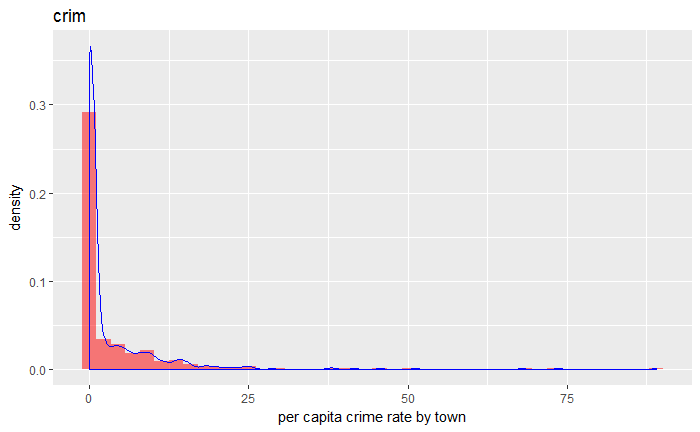

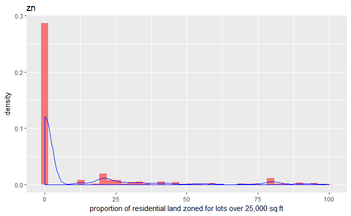

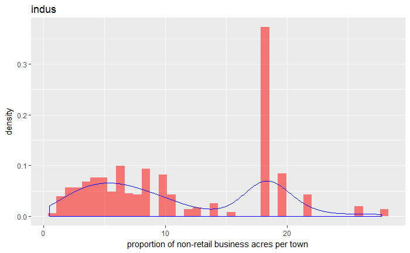

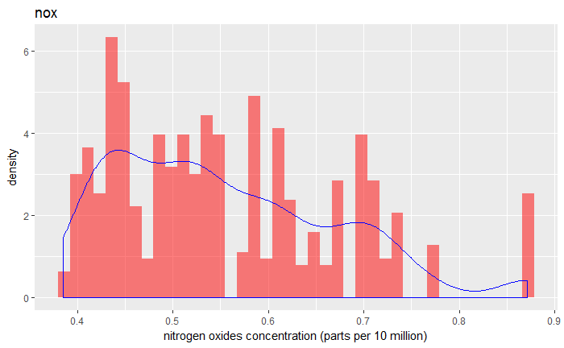

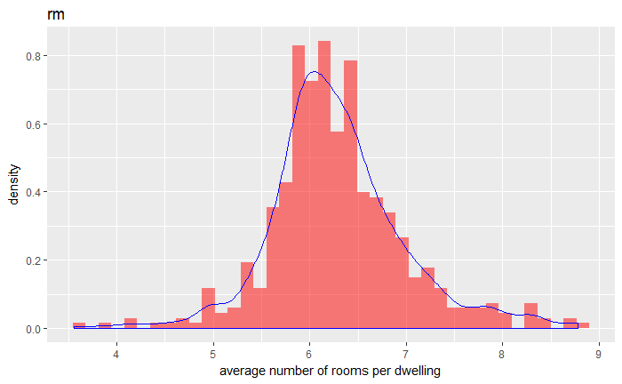

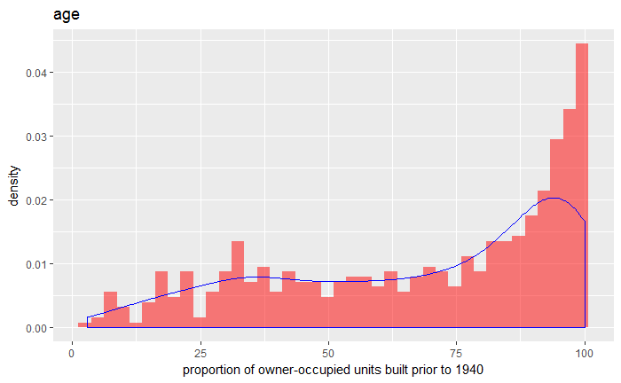

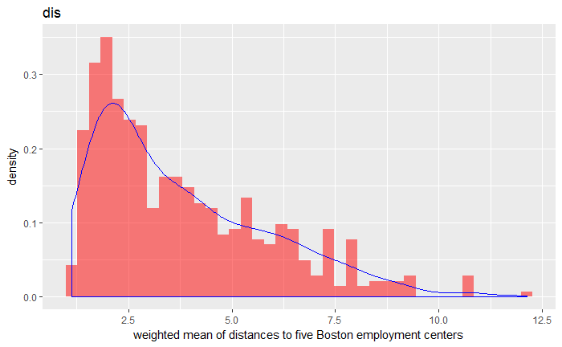

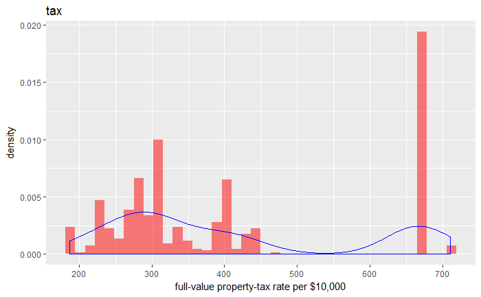

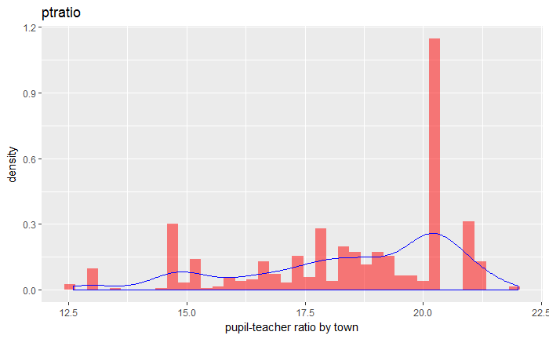

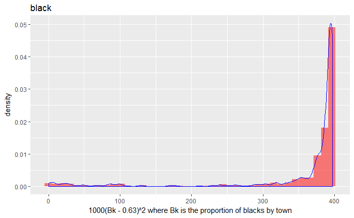

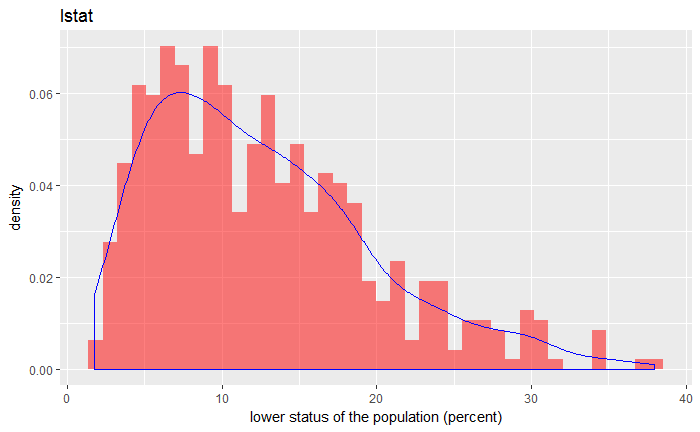

```r
for (feature in names(subset(rawData, select = -c(X, chas, rad)))) {
  xlabel <- dataDefinitions$definition[dataDefinitions$feature == feature[1]]
  plot <- ggplot(rawData, aes(x = rawData[[feature]]), binwidth = 2) +
            geom_histogram(aes(y = ..density..), fill = 'red', alpha = 0.5, bins = 40) +
            geom_density(colour = 'blue') +
            xlab(xlabel) +
            ylab('density') +
            ggtitle(feature)
  print(plot)
}
```

## Preprocessing

**Steps**

1. Define a new dataframe for storing preprocessed data
2. Remove the index column *X*
3. Parse *rad* to factor and transform to dummies
4. Transform *tax* to base percent and parse to double
5. Evaluate baseline performance
6. Standardize values across features (i.e., center and scale)
7. Perform Yeo-Johnson transformation
8. Re-evaluate performance

```r
preprocessedData <- rawData[c(-1)]
preprocessedData$rad <- as.factor(preprocessedData$rad)
preprocessedData <- as.data.frame(predict(dummyVars(~ ., data = preprocessedData), newdata = preprocessedData))
preprocessedData$tax <- as.double(preprocessedData$tax / 10000)
print(head(preprocessedData))
```

|  | crim | zn | indus | chas | nox | rm | age | dis | rad.1 | rad.2 | rad.3 | rad.4 | rad.5 | rad.6 | rad.7 | rad.8 | rad.24 | tax | ptratio | black | lstat | medv |
| --- | --- | --- | --- | --- | --- | --- | --- | --- | --- | --- | --- | --- | --- | --- | --- | --- | --- | --- | --- | --- | --- | --- |
| 1 | 0.00632 | 18 | 2.31 | 0 | 0.538 | 6.575 | 65.2 | 4.0900 | 1 | 0 | 0 | 0 | 0 | 0 | 0 | 0 | 0 | 0.0296 | 15.3 | 396.90 | 4.98 | 24.0 |
| 2 | 0.02731 | 0 | 7.07 | 0 | 0.469 | 6.421 | 78.9 | 4.9671 | 0 | 1 | 0 | 0 | 0 | 0 | 0 | 0 | 0 | 0.0242 | 17.8 | 396.90 | 9.14 | 21.6 |
| 3 | 0.02729 | 0 | 7.07 | 0 | 0.469 | 7.185 | 61.1 | 4.9671 | 0 | 1 | 0 | 0 | 0 | 0 | 0 | 0 | 0 | 0.0242 | 17.8 | 392.83 | 4.03 | 34.7 |
| 4 | 0.03237 | 0 | 2.18 | 0 | 0.458 | 6.998 | 45.8 | 6.0622 | 0 | 0 | 1 | 0 | 0 | 0 | 0 | 0 | 0 | 0.0222 | 18.7 | 394.63 | 2.94 | 33.4 |
| 5 | 0.06905 | 0 | 2.18 | 0 | 0.458 | 7.147 | 54.2 | 6.0622 | 0 | 0 | 1 | 0 | 0 | 0 | 0 | 0 | 0 | 0.0222 | 18.7 | 396.90 | 5.33 | 36.2 |
| 6 | 0.02985 | 0 | 2.18 | 0 | 0.458 | 6.430 | 58.7 | 6.0622 | 0 | 0 | 1 | 0 | 0 | 0 | 0 | 0 | 0 | 0.0222 | 18.7 | 394.12 | 5.21 | 28.7 |

```r
## Baseline Performance
lm.baseline <- lm(formula = medv ~ ., data = preprocessedData)
print(summary(lm.baseline))
```

```
Call:
lm(formula = medv ~ ., data = preprocessedData)

Residuals:
     Min       1Q   Median       3Q      Max
-15.1020  -2.7355  -0.4565   1.6821  25.9450

Coefficients: (1 not defined because of singularities)
              Estimate Std. Error t value Pr(>|t|)
(Intercept)  42.721289   5.893592   7.249 1.67e-12 ***
crim         -0.108821   0.032685  -3.329 0.000937 ***
zn            0.054896   0.014149   3.880 0.000119 ***
indus         0.023760   0.063648   0.373 0.709081
chas          2.524163   0.863181   2.924 0.003614 **
nox         -17.573132   3.896362  -4.510 8.13e-06 ***
rm            3.665491   0.421196   8.703  < 2e-16 ***
age           0.000461   0.013227   0.035 0.972210
dis          -1.554546   0.201909  -7.699 7.75e-14 ***
rad.1        -7.461674   1.788679  -4.172 3.58e-05 ***
rad.2        -5.972769   1.868213  -3.197 0.001479 **
rad.3        -2.780421   1.725184  -1.612 0.107685
rad.4        -4.885440   1.388692  -3.518 0.000476 ***
rad.5        -4.543182   1.417109  -3.206 0.001435 **
rad.6        -6.275836   1.516946  -4.137 4.15e-05 ***
rad.7        -2.582682   1.800992  -1.434 0.152207
rad.8        -2.621838   1.683548  -1.557 0.120045
rad.24              NA         NA      NA       NA
tax         -87.481752  38.947469  -2.246 0.025144 *
ptratio      -0.972419   0.144478  -6.731 4.78e-11 ***
black         0.009394   0.002661   3.531 0.000454 ***
lstat        -0.529226   0.050640 -10.451  < 2e-16 ***
---
Signif. codes:  0 ‘***’ 0.001 ‘**’ 0.01 ‘*’ 0.05 ‘.’ 0.1 ‘ ’ 1

Residual standard error: 4.694 on 485 degrees of freedom
Multiple R-squared:  0.7499,    Adjusted R-squared:  0.7396
F-statistic:  72.7 on 20 and 485 DF,  p-value: < 2.2e-16
```

```r
## Manual Transformation Performance
preprocessedData.ck <- rawData[c(-1)]
preprocessedData.ck$rad <- as.factor(preprocessedData.ck$rad)
preprocessedData.ck <- as.data.frame(predict(dummyVars(~ ., data = preprocessedData.ck), newdata = preprocessedData.ck))
preprocessedData.ck$tax <- as.double(preprocessedData.ck$tax / 10000)
colsRightSkew <- c("crim", "nox", "dis", "lstat")
preprocessedData.ck[colsRightSkew] <- log(preprocessedData.ck[colsRightSkew])
colsLeftSkew <- c("age", "ptratio", "black")
preprocessedData.ck[colsLeftSkew] <- (preprocessedData.ck[colsLeftSkew])^3
preprocessor <- preProcess(preprocessedData.ck, method = c("center", "scale"))
preprocessedData.ck <- predict(preprocessor, newdata = preprocessedData.ck)
preprocessedData.ck$medv <- rawData$medv
lm.ck <- lm(formula = medv ~ ., data = preprocessedData.ck)
print(summary(lm.ck))
```

```
Call:
lm(formula = medv ~ ., data = preprocessedData.ck)

Residuals:
    Min      1Q  Median      3Q     Max
-14.904  -2.423  -0.150   2.175  23.419

Coefficients: (1 not defined because of singularities)
            Estimate Std. Error t value Pr(>|t|)
(Intercept)  22.5328     0.1920 117.383  < 2e-16 ***
crim         -0.2684     0.5891  -0.456 0.648861
zn            0.2512     0.2886   0.871 0.384453
indus        -0.1478     0.4053  -0.365 0.715551
chas          0.5810     0.2018   2.879 0.004161 **
nox          -1.9220     0.4883  -3.936 9.49e-05 ***
rm            1.9923     0.2774   7.183 2.59e-12 ***
age           0.3107     0.3738   0.831 0.406291
dis          -3.4077     0.4461  -7.639 1.18e-13 ***
rad.1        -1.2633     0.3743  -3.375 0.000797 ***
rad.2        -1.0332     0.4151  -2.489 0.013145 *
rad.3        -0.6360     0.4696  -1.354 0.176221
rad.4        -1.3879     0.5848  -2.373 0.018025 *
rad.5        -1.4186     0.6186  -2.293 0.022259 *
rad.6        -0.8857     0.3503  -2.529 0.011766 *
rad.7        -0.3785     0.3145  -1.204 0.229269
rad.8        -0.4655     0.3441  -1.353 0.176646
rad.24            NA         NA      NA       NA
tax          -1.7395     0.6052  -2.874 0.004230 **
ptratio      -1.6210     0.2828  -5.731 1.75e-08 ***
black         0.5572     0.2301   2.421 0.015834 *
lstat        -5.4811     0.3479 -15.755  < 2e-16 ***
---
Signif. codes:  0 ‘***’ 0.001 ‘**’ 0.01 ‘*’ 0.05 ‘.’ 0.1 ‘ ’ 1

Residual standard error: 4.318 on 485 degrees of freedom
Multiple R-squared:  0.7883,    Adjusted R-squared:  0.7796
F-statistic:  90.3 on 20 and 485 DF,  p-value: < 2.2e-16
```

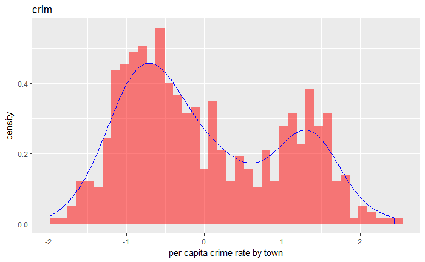

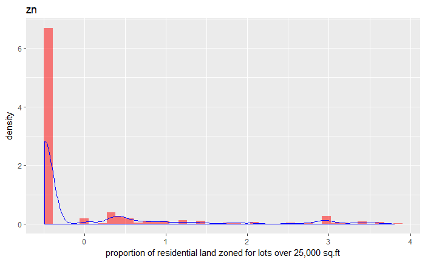

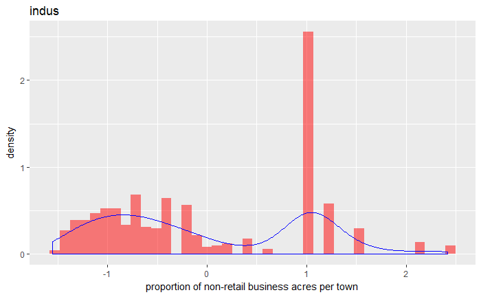

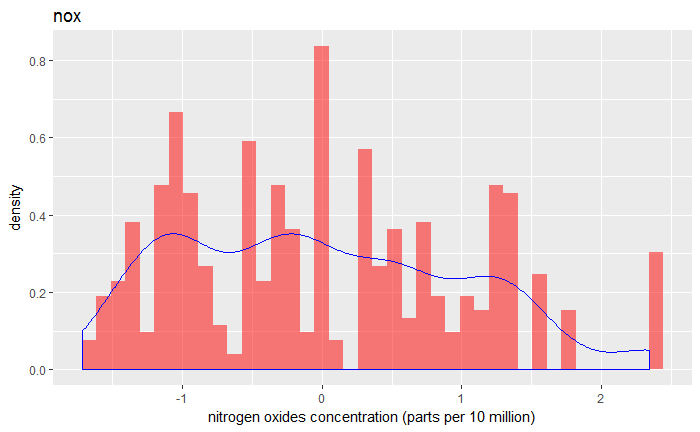

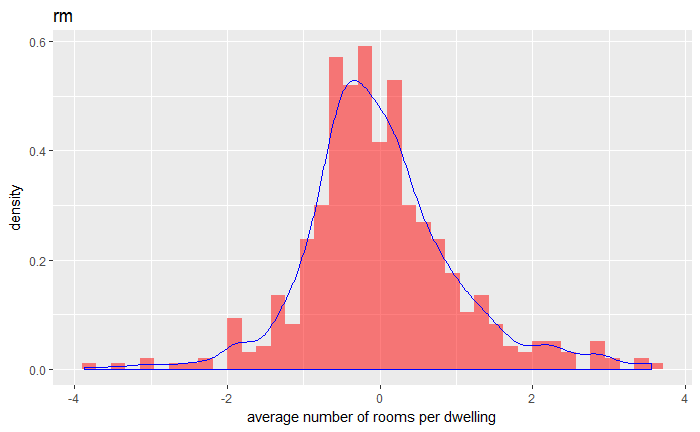

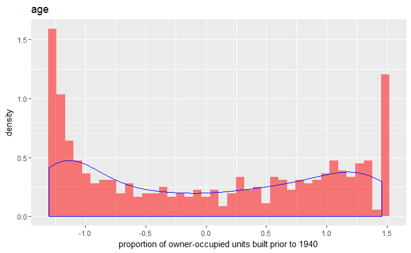

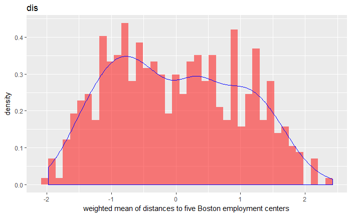

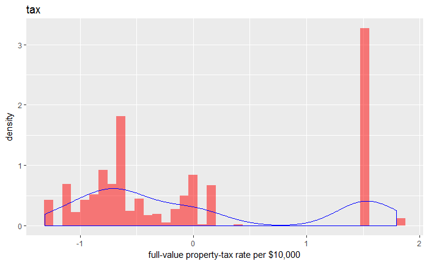

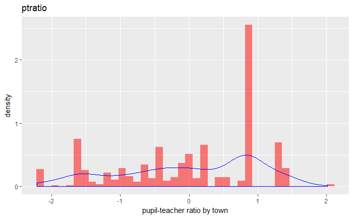

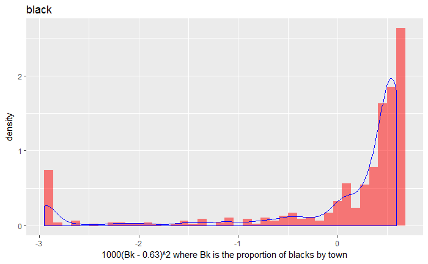

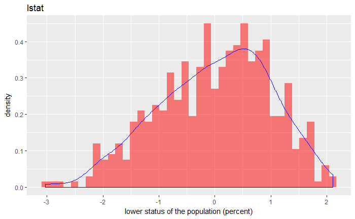

```r
plot.ck <- subset(preprocessedData.ck, select = -c(chas, rad.1, rad.2, rad.3, rad.4, rad.5, rad.6, rad.7, rad.8, rad.24))
for (feature in names(plot.ck)) {
  xlabel <- dataDefinitions$definition[dataDefinitions$feature == feature[1]]
  plot <- ggplot(preprocessedData.ck, aes(x = preprocessedData.ck[[feature]]), binwidth = 2) +
            geom_histogram(aes(y = ..density..), fill = 'red', alpha = 0.5, bins = 40) +
            geom_density(colour = 'blue') +
            xlab(xlabel) +
            ylab('density') +
            ggtitle(feature)
  print(plot)
}
```

```r
## Yeo-Johnson Transformation Performance
preprocessor <- preProcess(preprocessedData, method = c("center", "scale", "YeoJohnson"))
preprocessedData.yj <- predict(preprocessor, newdata = preprocessedData)
preprocessedData.yj$medv <- rawData$medv
lm.yj <- lm(formula = medv ~ ., data = preprocessedData.yj)
print(summary(lm.yj))
```

```
Call:
lm(formula = medv ~ ., data = preprocessedData.yj)

Residuals:
    Min      1Q  Median      3Q     Max
-14.156  -2.544  -0.282   2.249  22.431

Coefficients: (1 not defined because of singularities)
             Estimate Std. Error t value Pr(>|t|)
(Intercept) 22.532806   0.197584 114.041  < 2e-16 ***
crim         0.851072   0.671054   1.268  0.20531
zn           0.346402   0.307742   1.126  0.26088
indus       -0.562343   0.409135  -1.374  0.16993
chas         0.626081   0.208347   3.005  0.00279 **
nox         -2.166855   0.558933  -3.877  0.00012 ***
rm           1.859467   0.283201   6.566 1.33e-10 ***
age          0.435235   0.388657   1.120  0.26334
dis         -3.617272   0.463880  -7.798 3.88e-14 ***
rad.1       -0.789621   0.343727  -2.297  0.02203 *
rad.2       -0.464819   0.393696  -1.181  0.23832
rad.3       -0.077171   0.449227  -0.172  0.86368
rad.4       -0.417544   0.530076  -0.788  0.43125
rad.5       -0.424616   0.572873  -0.741  0.45893
rad.6       -0.347506   0.356428  -0.975  0.33006
rad.7       -0.057913   0.303585  -0.191  0.84879
rad.8       -0.005215   0.333796  -0.016  0.98754
rad.24             NA         NA      NA       NA
tax         -1.428932   0.454319  -3.145  0.00176 **
ptratio     -1.424228   0.298709  -4.768 2.46e-06 ***
black        0.524064   0.239338   2.190  0.02903 *
lstat       -5.708700   0.361452 -15.794  < 2e-16 ***
---
Signif. codes:  0 ‘***’ 0.001 ‘**’ 0.01 ‘*’ 0.05 ‘.’ 0.1 ‘ ’ 1

Residual standard error: 4.445 on 485 degrees of freedom
Multiple R-squared:  0.7757,    Adjusted R-squared:  0.7665
F-statistic: 83.87 on 20 and 485 DF,  p-value: < 2.2e-16
```